# More Randomization Simulations, Central Limit Theorem, and Confidence Intervals

As always, we should start by making sure that mosaic and mosaicData are loaded into R.

```r
require(mosaic)
require(mosaicData)
require(ggplot2)
require(dplyr)
```

[from Tintle, Chance, Cobb, Rossman, Roy, Swanson, and Vanderstoep]

We all know that dogs have an amazing sense of smell. They are used to help hunters find their prey, determine the location of missing people, and screen luggage for drugs. But can a dog’s keen sense of smell also be used to determine whether a patient has cancer? In 2011, an article published by the medical journal (Sonoda, et al.) reported the results of a study conducted in Japan in which a dog was tested to see whether she could detect colorectal cancer. The dog used was an 8-year-old black labrador named Marine. (As her name might suggest, she was originally trained for water rescues.)

The study was designed so that the dog first smelled a bag that had been breathed into by a patient with colorectal cancer. This was the standard that the dog would use to judge the other bags. Marine then smelled the breath in five different bags from five different patients, only one of which contained breath from a colorectal patient (not the same as the original patient); the others contained breath from non-cancer patients. The dog was trained to sit next to the bag which she thought contained breath from a cancer patient (i.e. had the cancer scent). If she sat down next to the correct bag she was rewarded with a tennis ball.

Marine completed 33 attempts of this experimental procedure, with a different set of patients each time: four non-cancer patients, and one cancer patient. And each time, whether or not she correctly identified the bag with the breath of the cancer patient was recorded. In her 33 attempts, Marine correctly identified the bag containing the breath of a cancer patient 30 times.

What does this tell us about Marine’s underlying probability of identifying the breath of the cancer patient?

Let start with a null haypotheses that Marine is randomly guessing. This means that Marine would guess correctly 1/5th of the time, i.e. her probability of success during each independent trial is 0.2. We can set this up as a flip of a weighted coin (probability of heads is .2) or as a draw of a card from a carefully assembled deck (4 black cards and 1 red card). We will do the coin flipping method because it will let us adjust the probability of success more easily when we start looking for plausible values.

```r
random.Marine = do(10000)*rflip(33 , 0.2)
tally( ~ heads, data=random.Marine, format="prop")
```

```
## heads
##      0      1      2      3      4      5      6      7      8      9
## 0.0003 0.0052 0.0212 0.0559 0.1053 0.1458 0.1708 0.1677 0.1371 0.0863
##     10     11     12     13     14     15     16
## 0.0552 0.0283 0.0129 0.0044 0.0025 0.0009 0.0002
```

So in 10000 trials we don’t see any cases where a randomly guessing dog was able to get more than 18 correct out of the 33. This is extremely strong evidence that the probability that Marine correctly identifies the cancer patient, is greater than 0.20. But what is Marine’s long-run probability? We think that the actual proportion is close to $\frac{30}{33}=0.909$. But what about other values? Is it plausible that Marine’s probability is actually 0.70, but she had a lucky day? Well, let’s test whether these sample data provide convincing evidence that the proportion differs from 0.70. So our null hypothesis is now that (in the long run) Marine’s probability of correctly identifying the cancer patient is 0.70.

We will be doing a 2-tail test for this because we will want to be able to figure out what probabilities (both above and below our sample mean) are plausible.

```r
random.Marine = do(10000)*rflip(33 , 0.7)
tally( ~ heads, data=random.Marine, format="prop")
```

```
## heads
##     12     13     14     15     16     17     18     19     20     21
## 0.0001 0.0003 0.0004 0.0015 0.0054 0.0126 0.0258 0.0470 0.0766 0.1067
##     22     23     24     25     26     27     28     29     30     31
## 0.1286 0.1452 0.1429 0.1206 0.0901 0.0564 0.0237 0.0108 0.0040 0.0012
##     32
## 0.0001
```

So what about the null hypothesis that Marine is actually correct with probability 0.80?

```r
random.Marine = do(10000)*rflip(33 , 0.8)
Tally <- tally( ~ heads, data=random.Marine, format="prop")
Tally
```

```
## heads
##     17     18     19     20     21     22     23     24     25     26
## 0.0002 0.0004 0.0020 0.0053 0.0146 0.0272 0.0566 0.0941 0.1311 0.1658
##     27     28     29     30     31     32     33
## 0.1678 0.1521 0.1024 0.0544 0.0187 0.0068 0.0005
```

```r
#One possible way to get the one-tail p-value
Tally["30"]+Tally["31"]+Tally["32"]+Tally["33"]
```

```
##     30
## 0.0804
```

```r
#Another slicker way
VarSelect <- which(as.numeric(names(Tally))>=30)
sum(Tally[VarSelect])
```

```
## [1] 0.0804
```

Now we get a probability of sucess including or above 30 to be 0.0804, then we double this to account for the other tail. A p-value of 0.1608 would not be considered strong evidence against the null hypothesis. From this we conclude that 0.8 is a plausible value for the true probability of success. Are there other values that are plausible as well? In class we tried some values between .7 and .8 to figure out where the boundary of plausible true proportions was.

```r
random.Marine = do(10000)*rflip(33 , 0.755)
Tally= tally( ~ heads, data=random.Marine, format="prop")
VarSelect <- which(as.numeric(names(Tally))>=30)
sum(Tally[VarSelect])
```

```
## [1] 0.0229
```

We ended up finding that somewhere near 0.755 was the lowest the true proportion (null hypothesis) could be so that the observed or more extreme success rates are not surprising (happen more frequently than 5% of the time).

For the upper bound on plausible probabilities of success we shifted to looking at null hypotheses that were above $0.909$ and looked at the probability of seeing randomized simulations with 30 or less correct identifications. This is the same as one minus the probability of 31 or above.

```r
random.Marine = do(10000)*rflip(33 , 0.981)
tally( ~ heads, data=random.Marine, format="prop")
```

```
## heads
##     28     29     30     31     32     33
## 0.0003 0.0031 0.0223 0.1026 0.3411 0.5306
```

```r
Tally = tally( ~ heads, data=random.Marine, format="prop")
VarSelect <- which(as.numeric(names(Tally))<=30)
sum(Tally[VarSelect])
```

```
## [1] 0.0257
```

To interpret these results, we say that we are 95% confident that Marine’s probability of correctly picking the bag with breath from a cancer patient from among five bages falls between 0.755 and 0.981. Notice this is a much stronger statement than our initial significance test which concluded simply that Marine’s probability was larger than 0.20.

What would you expect would happen to this confindence interval if we increase the confidence level to 99%?

Another way that we can compute the confidence interval is to assume that the null distribution is normal. With such null distributions, most random samples (about 95%) fall within 2 standard deviations of the mean of the null distribution. In class we then computed the confidence interval using the “2 standard deviations from the mean”" technique that our book presents.

```r
results<- c(rep(0,3),rep(1,30)); results
```

```
##  [1] 0 0 0 1 1 1 1 1 1 1 1 1 1 1 1 1 1 1 1 1 1 1 1 1 1 1 1 1 1 1 1 1 1
```

```r
mean.correct <- mean(results)
stdev.correct <- sd(results)
```

Or, equivelently according to the equation for the standard deviation

```r
mean.correct <- 30/33
stdev.correct <- sqrt((30*(1-30/33)^2+3*(-30/33)^2)/(33-1))
```

Now that we have the mean and standard deviation we can compute the confidence interval.

```r
mean.correct-1.96*stdev.correct/sqrt(33)
```

```
## [1] 0.8094842
```

```r
mean.correct+1.96*stdev.correct/sqrt(33)
```

```
## [1] 1.008698
```

This is not terribly close to the confidence interval we got through randomization simulation. Let’s check and see if the null distribution is normal under the assumptions we made in the randomization simulations:

```r
random.Marine = do(10000)*rflip(33 , 0.9)
head(random.Marine)
```

```
##    n heads tails      prop
## 1 33    30     3 0.9090909
## 2 33    33     0 1.0000000
## 3 33    31     2 0.9393939
## 4 33    31     2 0.9393939
## 5 33    32     1 0.9696970
## 6 33    29     4 0.8787879
```

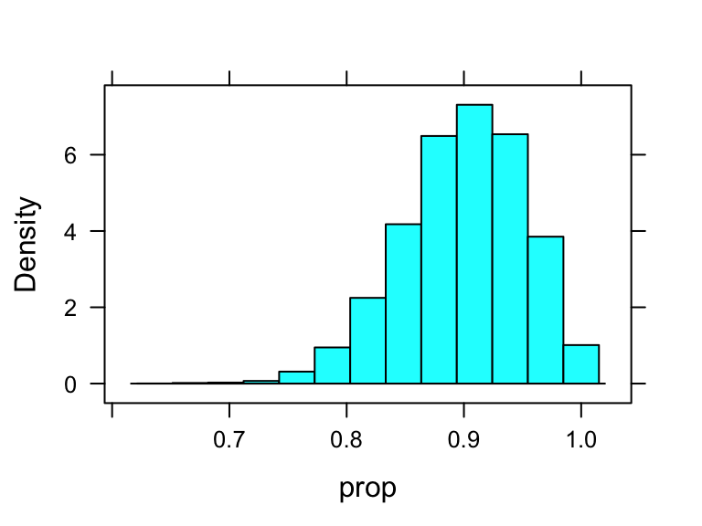

```r
histogram(~ prop, data=random.Marine, format="prop",width=1/33)
```

It looks like it is skewed, which would explain why the confidence intervals don’t match. We can use the “2 standard deviations from the mean” approach when the observations are normally distributed, or when the sample size is large (typically thought to be greater than 30 but in this case that wasn’t large enough).

The central limit theorem tells us that if our sample size (number of individuals sampled) is large enough, then the distribution of the means of random samples will be approximately normal with the same mean as the overall population and a standard deviation equal to the standard deviation of the population divided by the square root of the sample size.

Here we will do an example to investigate the Central Limit Theorem and to further convince ourselves that it works. We will start by looking at the wage data in the CPS85 dataset (in mosaicData).

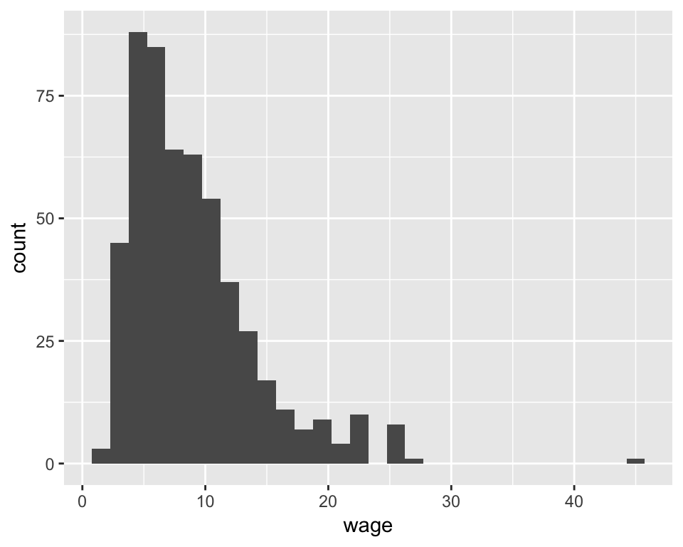

```r
ggplot(data=CPS85, aes(x=wage)) + geom_histogram()
```

```r
wage_summary <- CPS85 %>%
  summarize(
    mean=mean(wage),
    StDev = sd(wage)
  )
wage_summary
```

```
##       mean    StDev
## 1 9.024064 5.139097
```

Now let’s take a sample from this data (as we would if we randomly sampled just part of a population). For this we will start by sampling the wages of n=5 people from the population

```r
sample.meanwage <- deal(CPS85$wage, 5)
data.frame(mean=mean(sample.meanwage),StDev=sd(sample.meanwage))
```

```
##    mean    StDev
## 1 6.948 5.181363
```

Notice that the mean and standard deviation of this sample are pretty simular to the mean and standard deviation from the whole dataset. In fact, when we take samples from a population we use the sample mean and sample standard deviation to estimate the population mean and population standard deviation. This is generally a reasonable assumption (so it is good that they are about the same).

Now let’s look at what happens when we look at the means of many subsamples

```r
random.meanwages <- do(10000)*{mean(deal(CPS85$wage, 5))}
head(random.meanwages)
```

```
##   result
## 1 10.174
## 2  8.334
## 3  5.438
## 4  8.724
## 5  9.010
## 6  8.488
```

```r
wage_summary <- random.meanwages %>%
  summarize(
    mean=mean(result),
    StDev = sd(result)
  )
wage_summary
```

```
##       mean    StDev
## 1 8.986317 2.295206
```

Recall that the mean of the whole dataset is 9.0240637 and the standard deviation of the whole dataset is 5.1390969. We will soon see in our book that theory predicts that the standard deviation of the distribution of sample means should be approximately the standard deviation of the population divided by the square root of the sample size. Here our samples were of 5 individiuals (n=5), so we would expect the standard deviation of our sample means to be 5.1390969/$\sqrt{5}$ = 2.298274. This is pretty close to the standard deviation of our sample means: 2.2952062.

So the theory did predict the standard deviation and mean of the sample means, but are the sample means normally distributed?

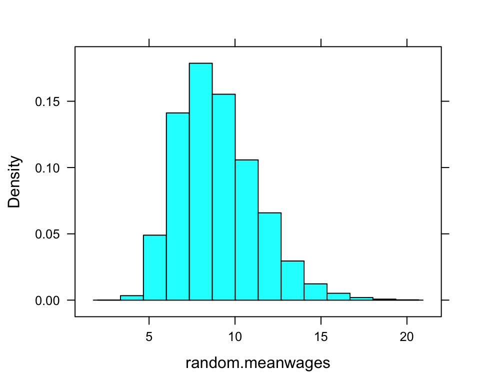

```r
histogram(~random.meanwages)
```

The distribution of the sample means is closer to normal but it is still pretty skewed. Why is that? Doesn’t the Central Limit Theorem tell us it should be normally distributed? Well, no. We did not take large samples. The Central Limit Theorem only tells us that the distribution of the sample means will be normally distributed when the original distribution was normal OR our sample sizes are large enough. Our original distribution was not normal, so let’s try it again with a sample size of `n=30`.

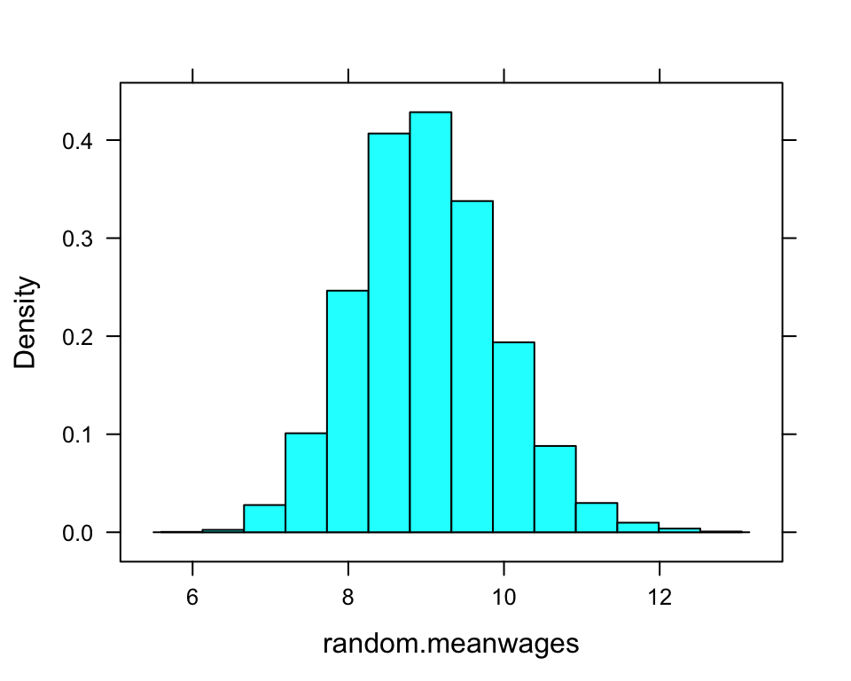

```r
random.meanwages <- do(10000)*{mean(deal(CPS85$wage, 30))}
histogram(~random.meanwages)
```

Now the distribution of the sample means looks normal (maybe with a little skew). Does the distribution of sample means have about the same mean as the original data (9.0240637)?

```r
mean(random.meanwages)
```

```
## [1] NA
```

Is the standard deviation of the sample means roughly equal to the standard deviation of the data divided by the square root of 30? (Note: 5.1390969/$\sqrt{30}$ = 0.9382664)

```r
sd(random.meanwages$result)
```

```
## [1] 0.9074468
```

```r
sd( ~ wage,data=CPS85)/sqrt(30)
```

```
## [1] 0.9382664
```

This looks like it confirms the books theorem (which is a well proven theorem but too mathematically difficult for us to tackle in this class).